# 1 Lesson 3

### 1.0.1 What to Do First?

Notes: Understand the variables that are most central to your analysis

### 1.0.2 Pseudo-Facebook User Data

Notes:

```r
getwd()
```

```
## [1] "/Users/webstrum/Study/old/udacity/docs/rcode/lesson3"
```

```r
list.files()
```

```
## [1] "lesson3_student.html" "lesson3_student.rmd"  "pseudo_facebook.tsv"
```

```r
pf = read.csv("pseudo_facebook.tsv", sep = "\t")
names(pf)
```

```
##  [1] "userid"                "age"                   "dob_day"
##  [4] "dob_year"              "dob_month"             "gender"
##  [7] "tenure"                "friend_count"          "friendships_initiated"
## [10] "likes"                 "likes_received"        "mobile_likes"
## [13] "mobile_likes_received" "www_likes"             "www_likes_received"
```

### 1.0.3 Histogram of Users’ Birthdays

Notes:

```r
#install.packages('ggplot2')
library(ggplot2)

summary(pf$dob_day)
```

```
##    Min. 1st Qu.  Median    Mean 3rd Qu.    Max.
##    1.00    7.00   14.00   14.53   22.00   31.00
```

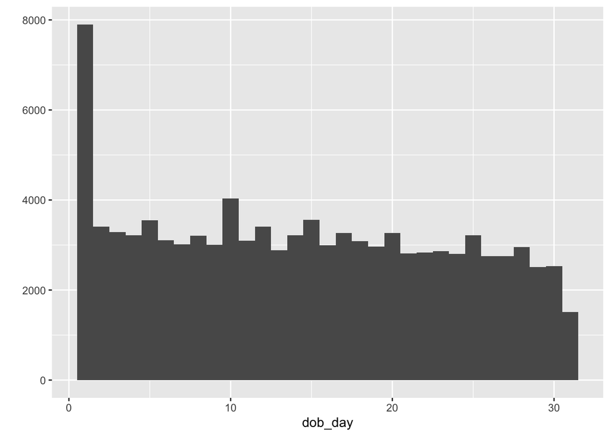

```r
qplot(x = dob_day, data = pf, binwidth = 1)
```

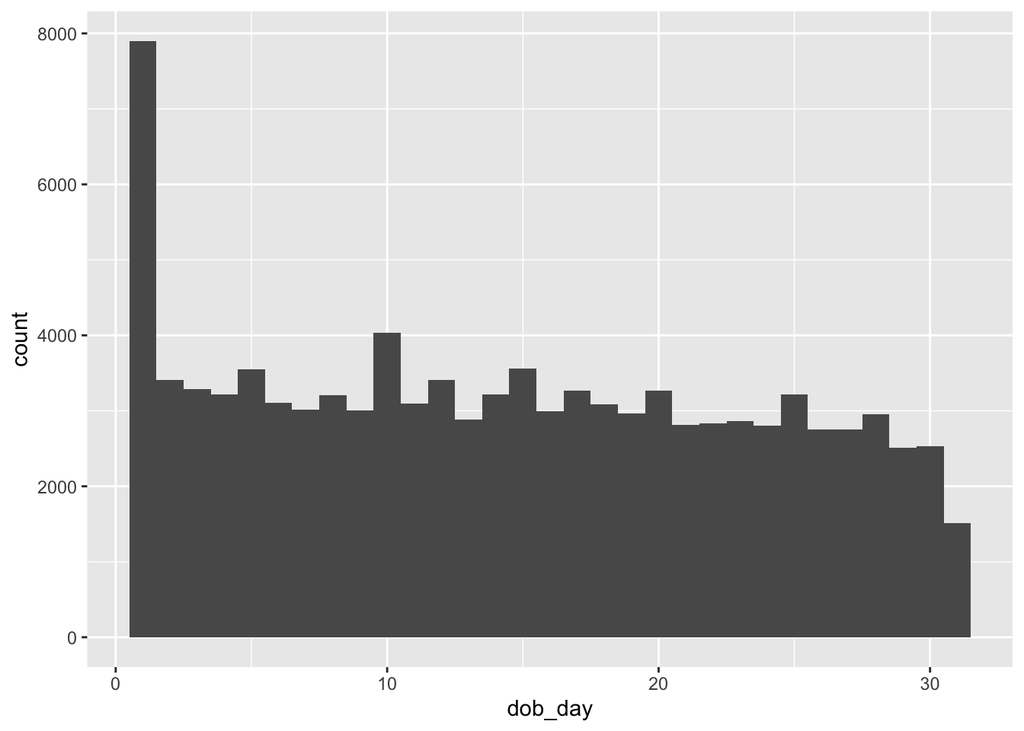

```r
# ggplot
ggplot(aes(x = dob_day), data = pf) +
  geom_histogram(binwidth = 1)
```

#### 1.0.3.1 What are some things that you notice about this histogram?

Response: Now, you may have noticed this huge spike on January first. There’s almost 8,000 users in this bin.

### 1.0.4 Moira’s Investigation

Notes: Think about a time when you posted a specific message or shared a photo on Facebook. What was it?

### 1.0.5 Estimating Your Audience Size

Notes: Pass

#### 1.0.5.1 Think about a time when you posted a specific message or shared a photo on Facebook. What was it?

Response: pass

#### 1.0.5.2 How many of your friends do you think saw that post?

Response: pass

#### 1.0.5.3 Think about what percent of your friends on Facebook see any posts or comments that you make in a month. What percent do you think that is?

Response: Pass

### 1.0.6 Perceived Audience Size

Notes: Typically, they guessed that their audience was about a quarter of the size that it actually was.

### 1.0.7 Faceting

Notes:

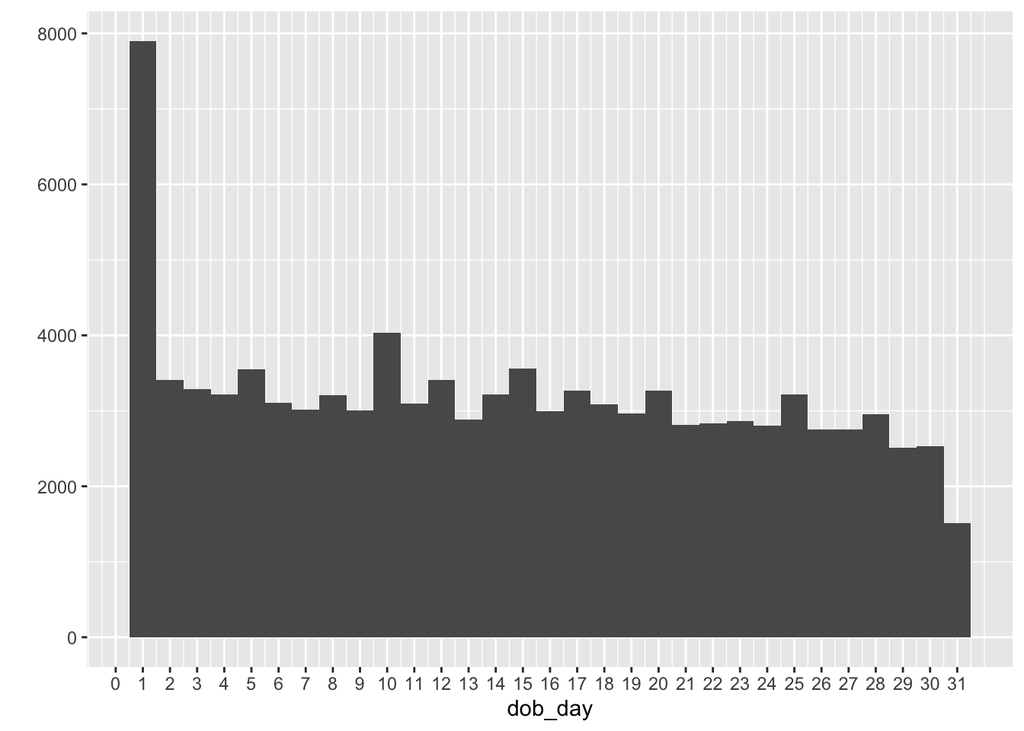

```r
qplot(x = dob_day, data = pf, binwidth = 1) +
  scale_x_continuous(breaks = seq(0, 31, 1))
```

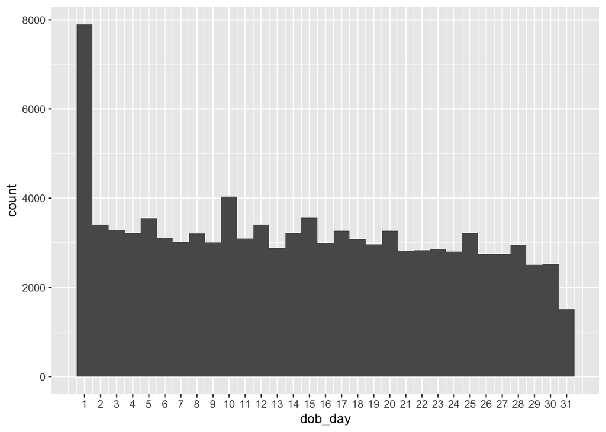

```r
ggplot(aes(x = dob_day), data = pf) +
  geom_histogram(binwidth = 1) +
  scale_x_continuous(breaks = 1:31)
```

#### 1.0.7.1 Let’s take another look at our plot. What stands out to you here?

Response: Noticed this huge spike on January first.

### 1.0.8 Be Skeptical - Outliers and Anomalies

Notes: Pass

### 1.0.9 Moira’s Outlier

Notes:

#### 1.0.9.1 Which case do you think applies to Moira’s outlier?

Response: Bad data about a extreme case.

### 1.0.10 Friend Count

Notes:

```r
summary(pf$friend_count)
```

```
##    Min. 1st Qu.  Median    Mean 3rd Qu.    Max.
##     0.0    31.0    82.0   196.4   206.0  4923.0
```

#### 1.0.10.1 What code would you enter to create a histogram of friend counts?

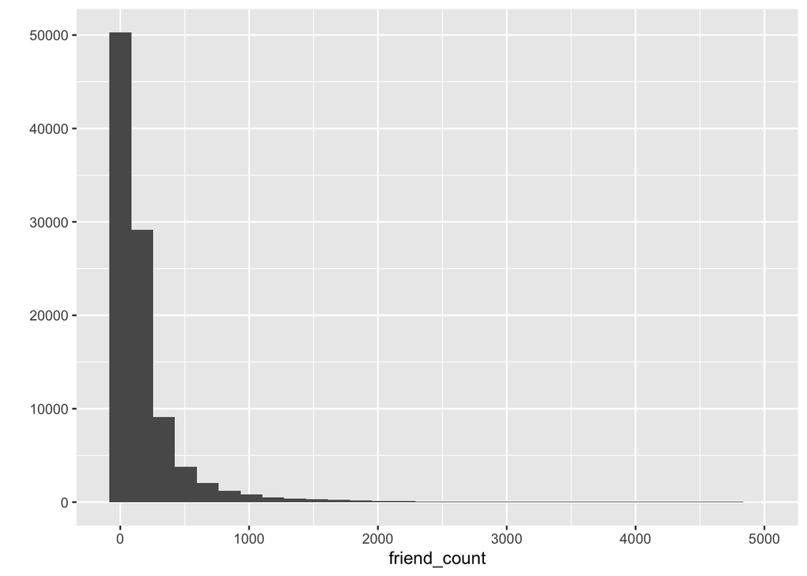

```r
qplot(x = friend_count, data = pf)
```

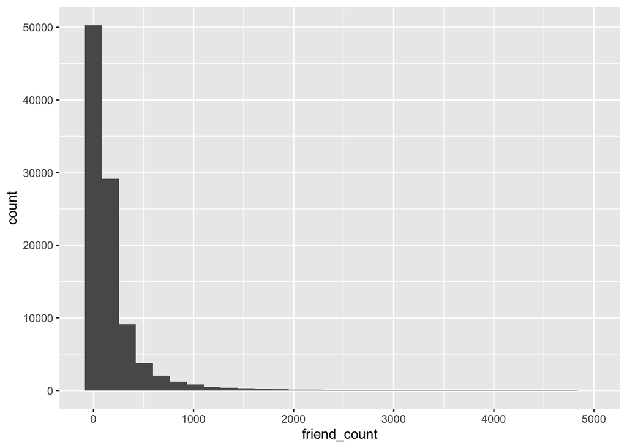

```r
ggplot(aes(x = friend_count), data = pf) +
  geom_histogram()
```

#### 1.0.10.2 How is this plot similar to Moira’s first plot?

Response: Pass

### 1.0.11 Limiting the Axes

Notes:

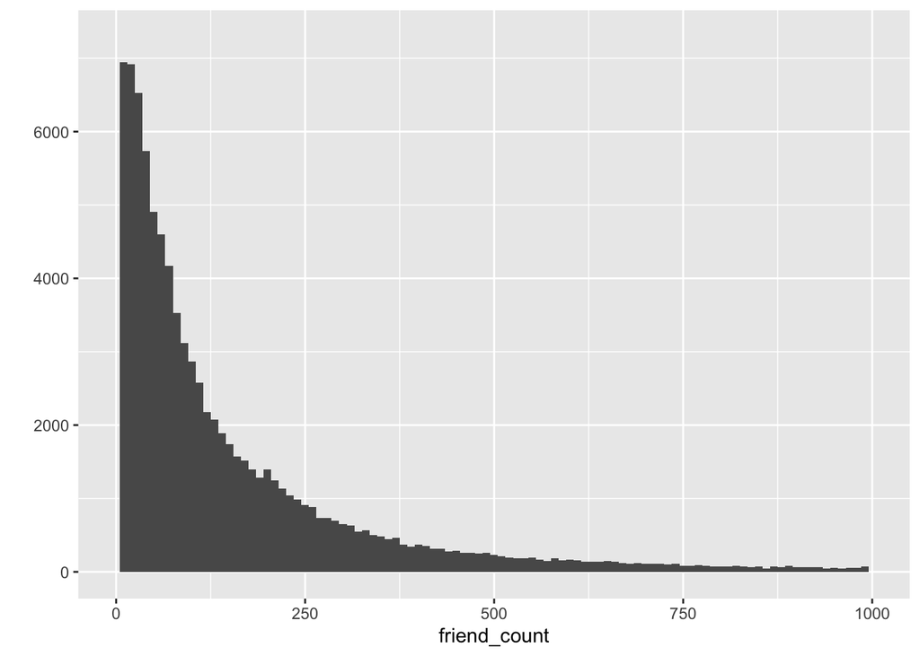

```r
qplot(x = friend_count, data = pf, binwidth = 10, xlim = c(0, 1000))
```

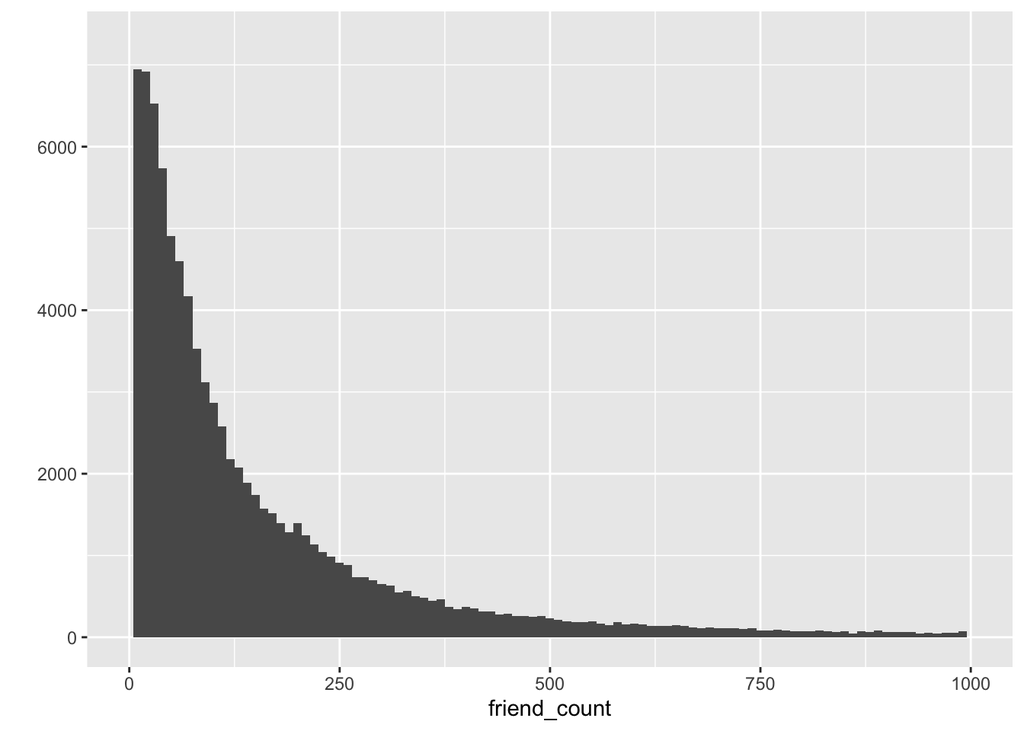

```r
qplot(x = friend_count, data = pf, binwidth = 10) +
  scale_x_continuous(limits = c(0, 1000))
```

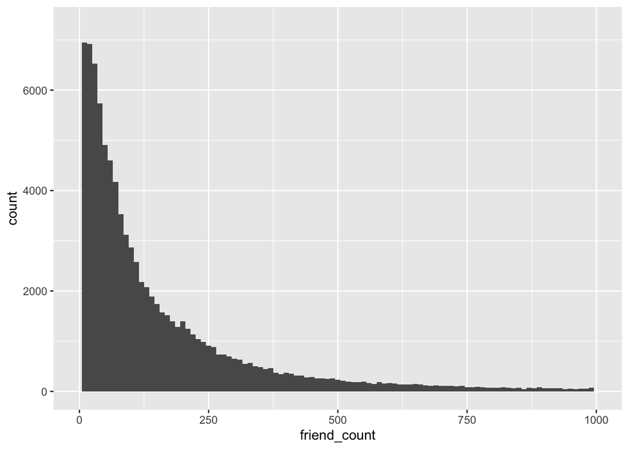

```r
ggplot(aes(x = friend_count), data = pf) +
  geom_histogram(binwidth = 10) +
  scale_x_continuous(limits = c(0, 1000))
```

### 1.0.12 Exploring with Bin Width

Notes: pass

### 1.0.13 Adjusting the Bin Width

Notes:

pass

### 1.0.14 Faceting Friend Count

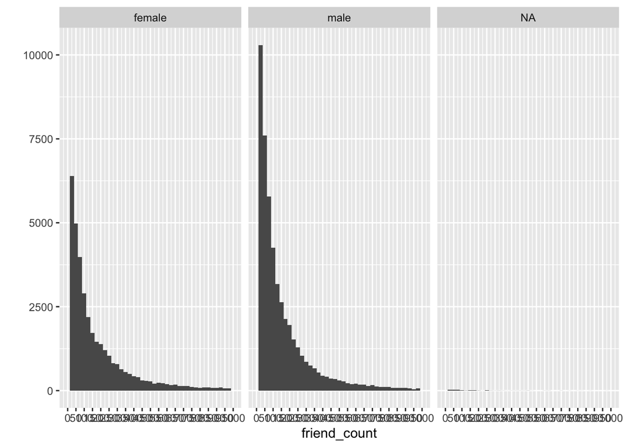

```r
# What code would you add to create a facet the histogram by gender?
# Add it to the code below.
qplot(x = friend_count, data = pf, binwidth = 25) +
  scale_x_continuous(limits = c(0, 1000),
                     breaks = seq(0, 1000, 50)) +
  facet_wrap(~gender)
```

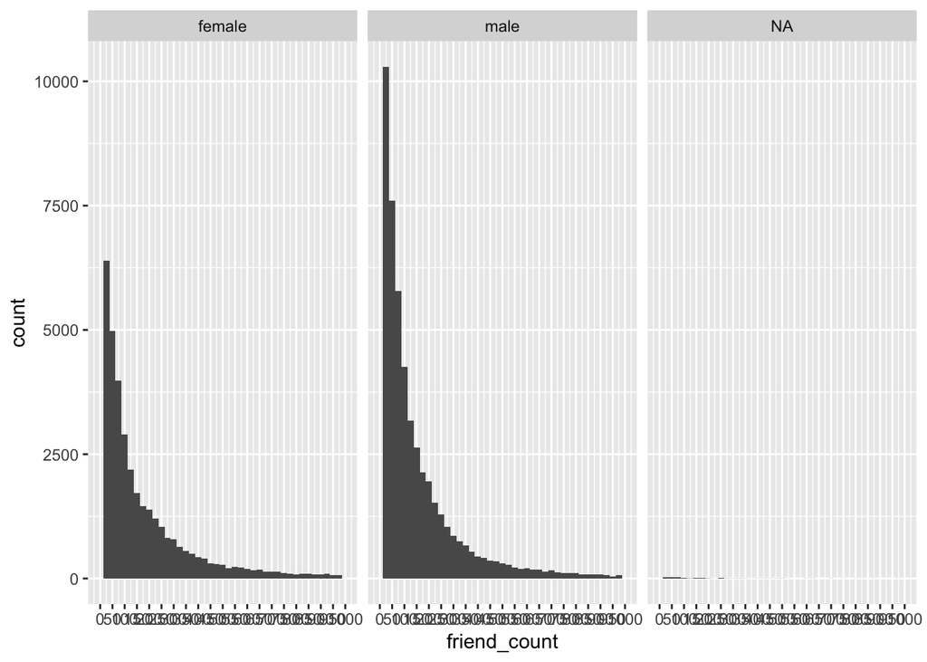

```r
ggplot(aes(x = friend_count), data = pf) +
  geom_histogram(binwidth = 25) +
  scale_x_continuous(limits = c(0, 1000),
                     breaks = seq(0, 1000, 50)) +
  facet_wrap(~gender)
```

### 1.0.15 Omitting NA Values

Notes:

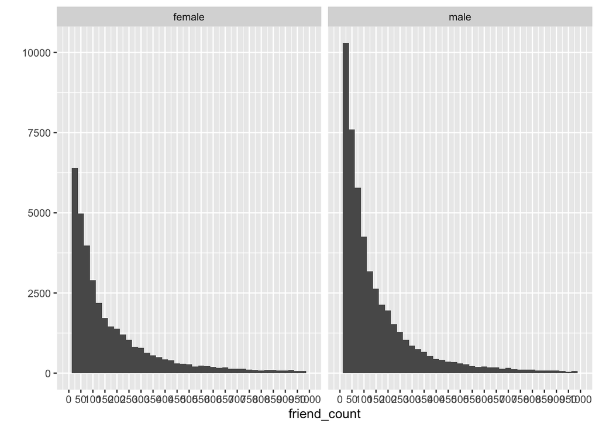

```r
qplot(x = friend_count, data = subset(pf, !is.na(gender)), binwidth = 25) +
  scale_x_continuous(limits = c(0, 1000), breaks = seq(0, 1000, 50)) +
  facet_wrap(~gender)
```

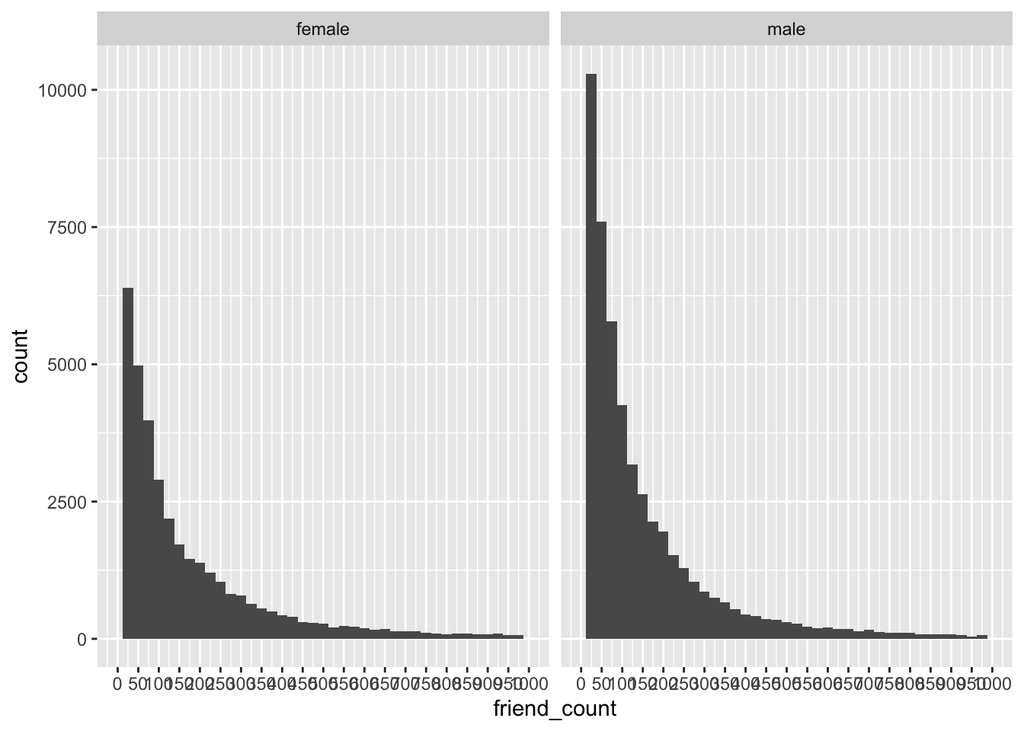

```r
ggplot(data = subset(pf, !is.na(gender)), aes(x = friend_count)) +
  geom_histogram(binwidth = 25) +
  scale_x_continuous(limits = c(0, 1000), breaks = seq(0, 1000, 50)) +
  facet_wrap(~gender)
```

### 1.0.16 Statistics ‘by’ Gender

Notes:

```r
table(pf$gender)
```

```
##
## female   male
##  40254  58574
```

```r
by(pf$friend_count, pf$gender, summary)
```

```
## pf$gender: female
##    Min. 1st Qu.  Median    Mean 3rd Qu.    Max.
##       0      37      96     242     244    4923
## ------------------------------------------------------------
## pf$gender: male
##    Min. 1st Qu.  Median    Mean 3rd Qu.    Max.
##       0      27      74     165     182    4917
```

#### 1.0.16.1 Who on average has more friends: men or women?

Response: women

#### 1.0.16.2 What’s the difference between the median friend count for women and men?

Response: women’s count greater than men about 22. #### Why would the median be a better measure than the mean? Response: The median’s resistant to change, since it marks the halfway point for all data

### 1.0.17 Tenure

Notes:

```r
summary(pf$tenure)
```

```
##    Min. 1st Qu.  Median    Mean 3rd Qu.    Max.    NA's
##     0.0   226.0   412.0   537.9   675.0  3139.0       2
```

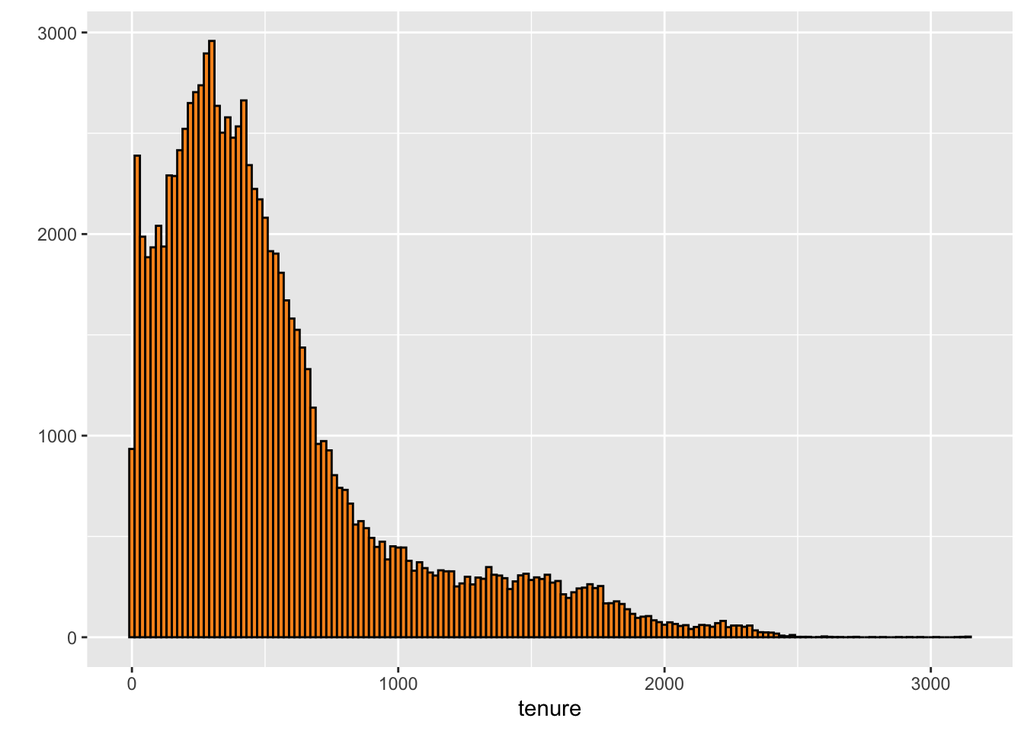

```r
qplot(x = tenure, data = pf, binwidth = 20, color = I("black"), fill = I("#F79420"))
```

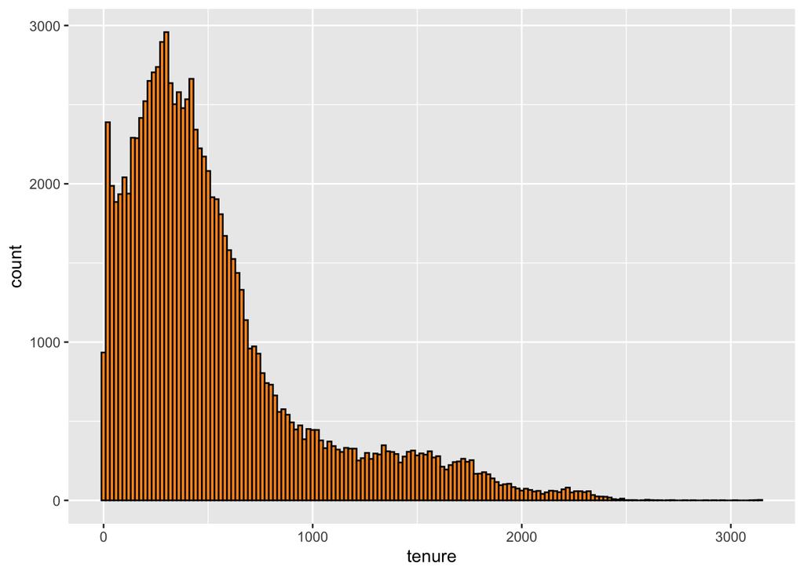

```r
ggplot(data = pf, aes(x = tenure)) +
  geom_histogram(binwidth = 20, color = 'black', fill = '#F79420')
```

#### 1.0.17.1 How would you create a histogram of tenure by year?

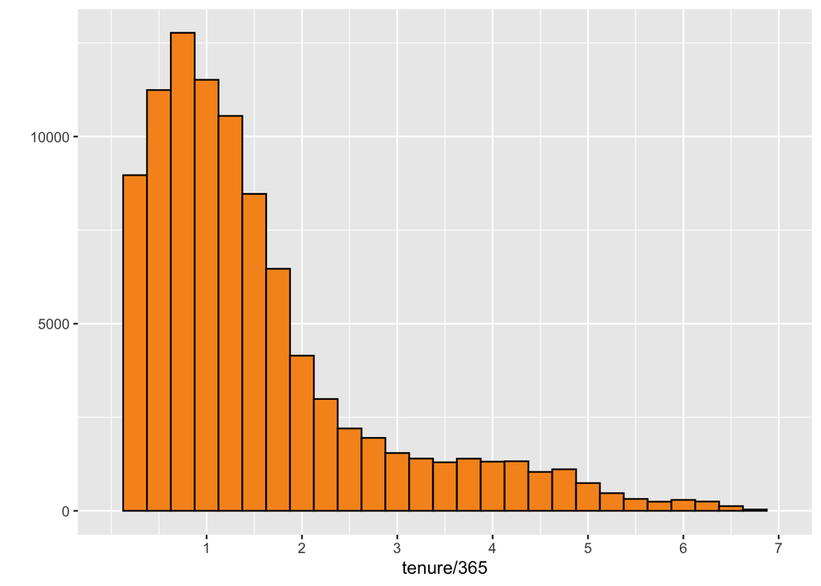

```r
qplot(x = tenure/365, data = subset(pf, !is.na(tenure)), binwidth = .25, color = I("black"), fill = I("#F79420")) +
  scale_x_continuous(breaks = seq(1, 7, 1), limits = c(0, 7))
```

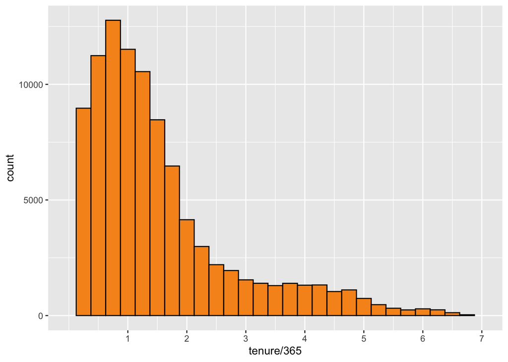

```r
ggplot(data = subset(pf, !is.na(tenure)), aes(x = tenure/365)) +
  geom_histogram(binwidth = .25, color = 'black', fill = '#F79420') +
  scale_x_continuous(breaks = seq(1, 7, 1), limits = c(0, 7))
```

### 1.0.18 Labeling Plots

Notes:

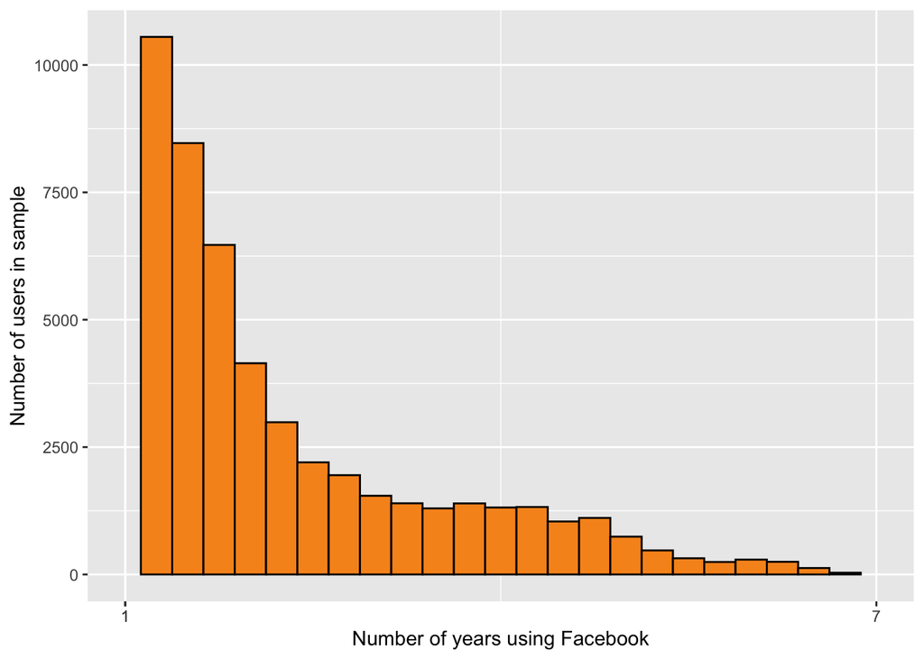

```r
qplot(x = tenure/365, data = pf, binwidth = .25, color = I("black"), fill = I("#F79420")) +
  scale_x_continuous(breaks = c(1, 7, 1), limits = c(1, 7)) +
  xlab("Number of years using Facebook") +
  ylab("Number of users in sample")
```

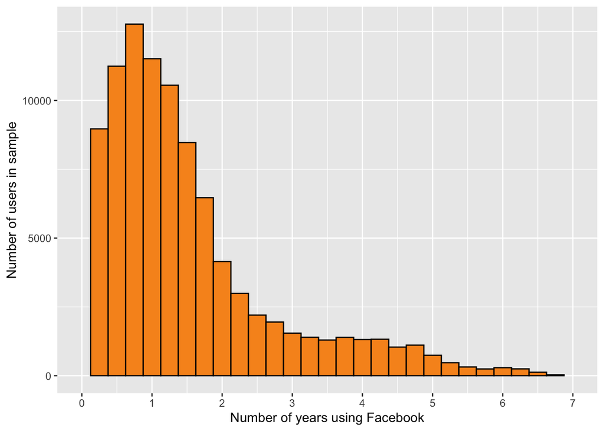

```r
ggplot(data = pf, aes(x = tenure/365)) +
  geom_histogram(binwidth = .25, color = 'black', fill = '#F79420') +
  scale_x_continuous(breaks = seq(0, 7, 1), limits = c(0, 7)) +
  xlab('Number of years using Facebook') +
  ylab("Number of users in sample")
```

### 1.0.19 User Ages

Notes:

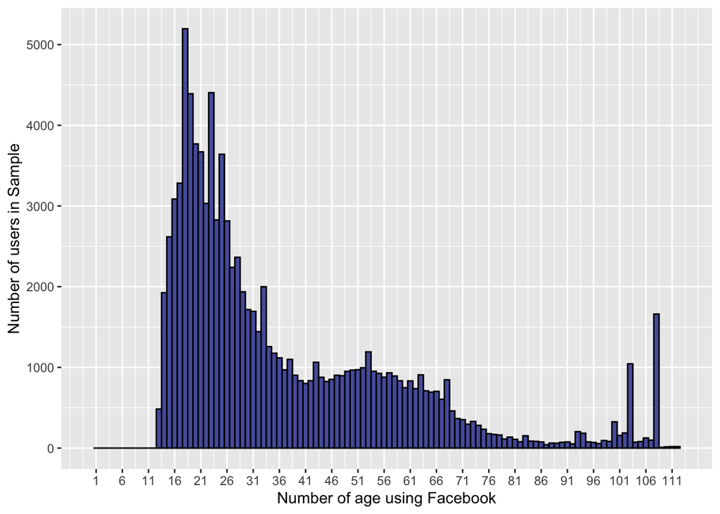

```r
ggplot(data = pf, aes(x = age)) +
  geom_histogram(binwidth = 1, color = "black", fill = "#5760AB") +
  scale_x_continuous(breaks = seq(1, 113, 5), limits = c(0, 113)) +
  xlab("Number of age using Facebook") +
  ylab("Number of users in Sample")
```

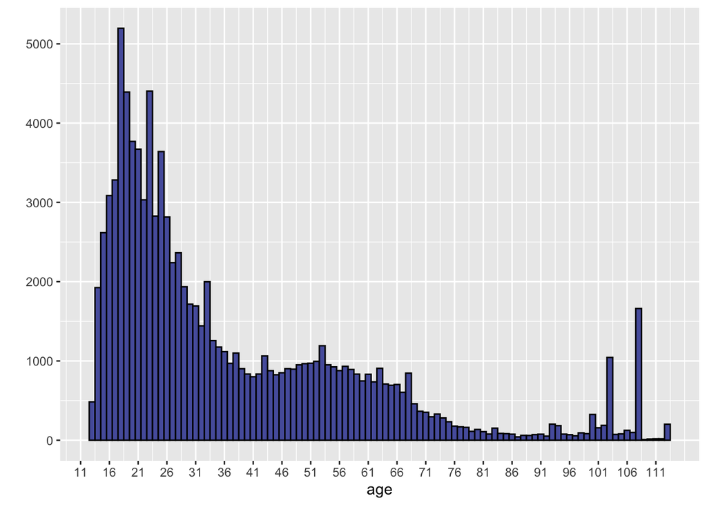

```r
qplot(x = age, data = pf, binwidth = 1,
      color = I("black") ,fill = I("#5760AB")) +
  scale_x_continuous(breaks = seq(1, 113, 5))
```

```r
summary(pf$age)
```

```
##    Min. 1st Qu.  Median    Mean 3rd Qu.    Max.
##   13.00   20.00   28.00   37.28   50.00  113.00
```

#### 1.0.19.1 What do you notice?

Response: pass

### 1.0.20 The Spread of Memes

Notes: pass

### 1.0.21 Lada’s Money Bag Meme

Notes: pass

### 1.0.22 Transforming Data

Notes:

```r
summary(pf$friend_count)
```

```
##    Min. 1st Qu.  Median    Mean 3rd Qu.    Max.
##     0.0    31.0    82.0   196.4   206.0  4923.0
```

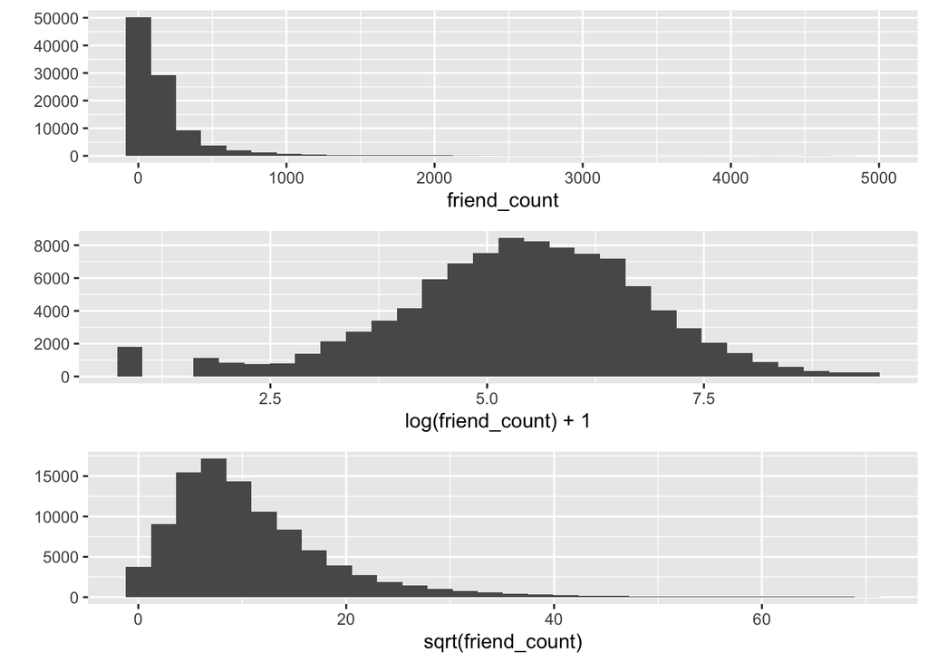

```r
library(gridExtra)

p1 <- qplot(x = friend_count, data = pf)
p2 <- qplot(x = log(friend_count) + 1, data = pf)
p3 <- qplot(x = sqrt(friend_count), data = pf)
grid.arrange(p1, p2, p3, ncol = 1)
```

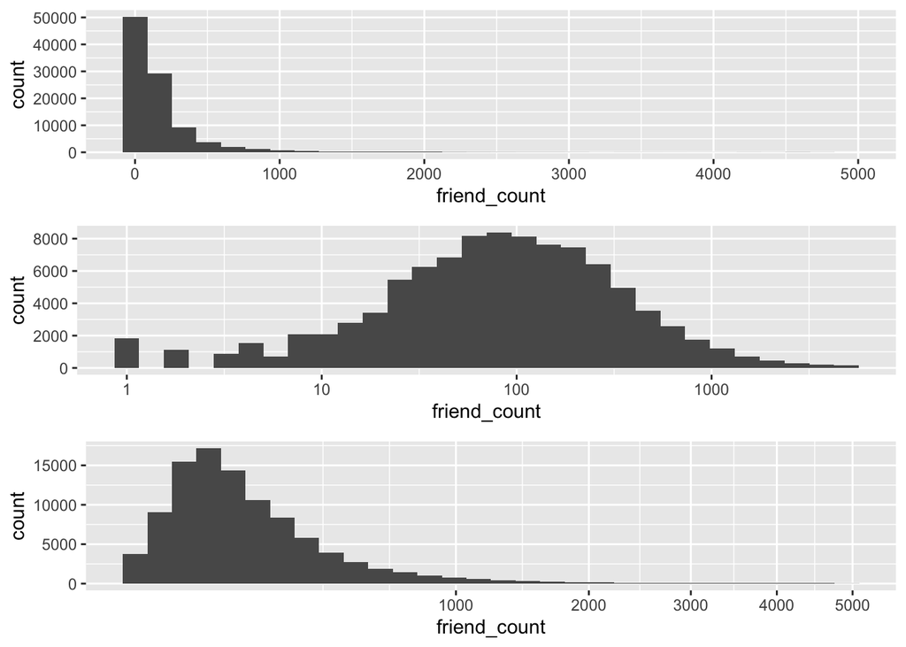

```r
p1 <- ggplot(data = pf, aes(x = friend_count)) +
  geom_histogram()
p2 <- p1 + scale_x_log10()
p3 <- p1 + scale_x_sqrt()
grid.arrange(p1, p2, p3, ncol=1)
```

### 1.0.23 Add a Scaling Layer

Notes:

### 1.0.24 Frequency Polygons

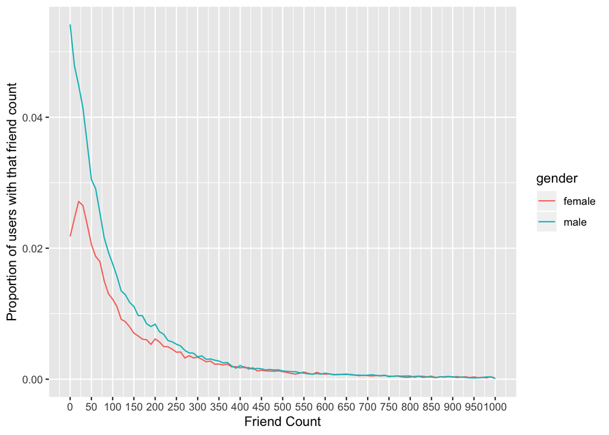

```r
qplot(x = friend_count, y = ..count../sum(..count..),
      data = subset(pf, !is.na(gender)),
      binwidth = 10,
      geom = "freqpoly",
      color = gender) +
  scale_x_continuous(breaks = seq(0, 1000, 50), limits = c(0, 1000)) +
  xlab('Friend Count') +
  ylab('Proportion of users with that friend count')
```

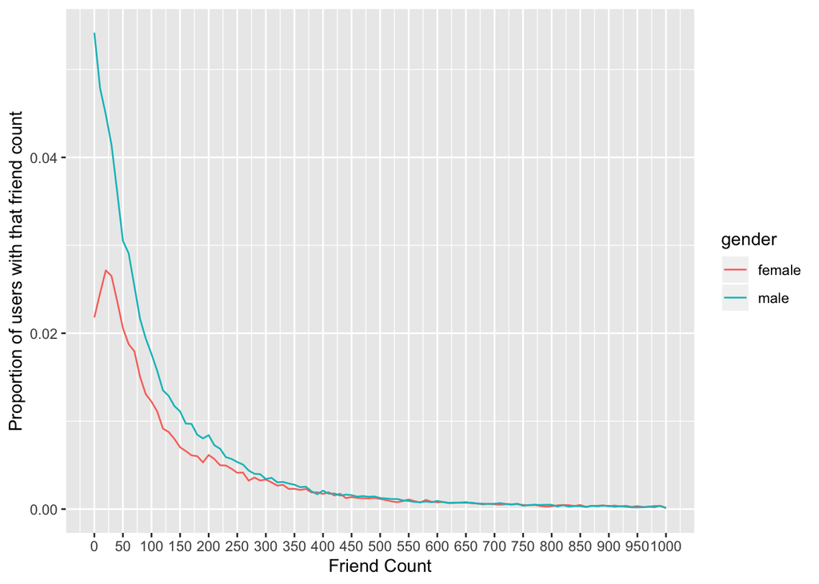

```r
ggplot(data = subset(pf, !is.na(gender)), aes(x = friend_count, y = ..count../sum(..count..))) +
  geom_freqpoly(aes(color = gender), binwidth = 10) +
  scale_x_continuous(breaks = seq(0, 1000, 50), limits = c(0, 1000)) +
  xlab("Friend Count") +
  ylab("Proportion of users with that friend count")
```

### 1.0.25 Likes on the Web

Notes:

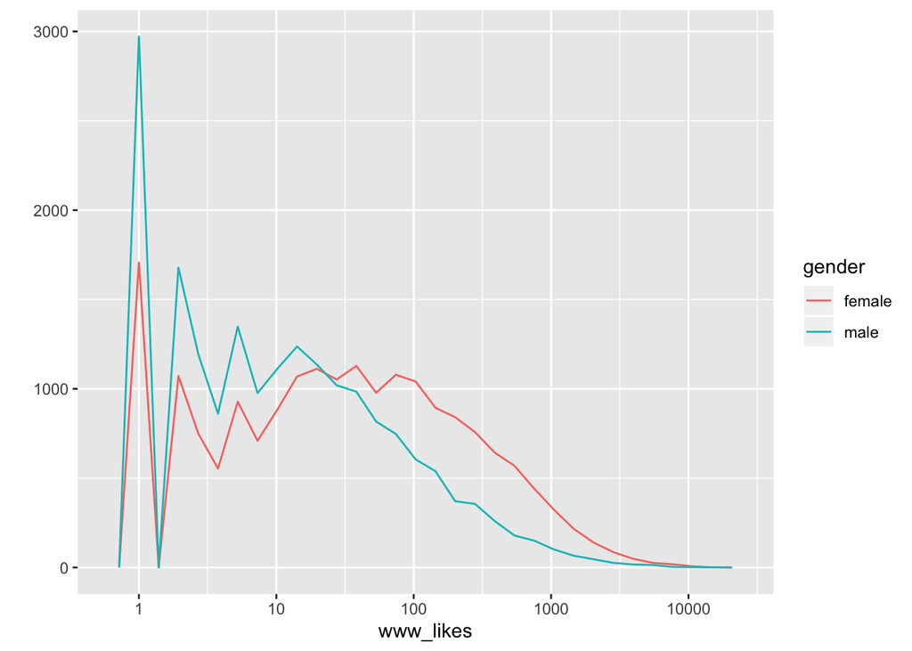

```r
qplot(x = www_likes,
      data = subset(pf, !is.na(gender)),
      geom = "freqpoly",
      color = gender) +
  scale_x_log10()
```

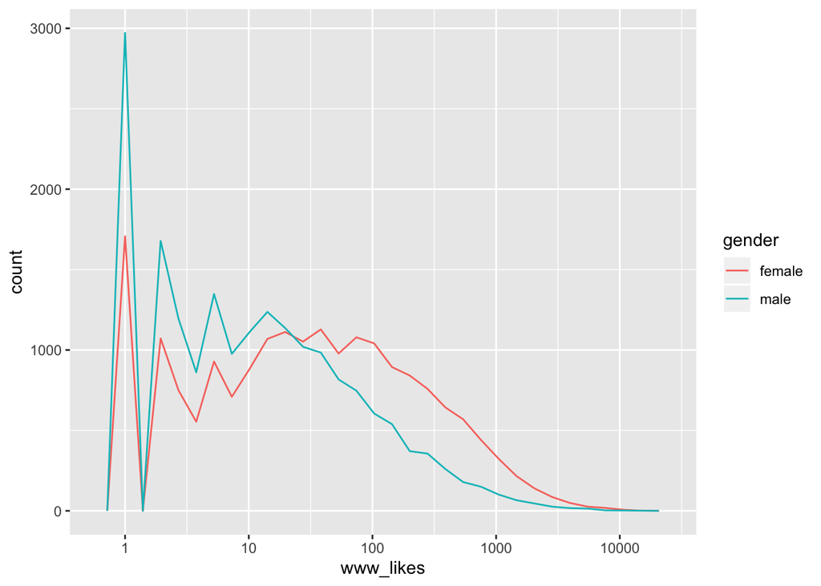

```r
ggplot(aes(x = www_likes), data = subset(pf, !is.na(gender))) +
  geom_freqpoly(aes(color = gender)) +
  scale_x_log10()
```

```r
by(pf$www_likes, pf$gender, sum)
```

```
## pf$gender: female
## [1] 3507665
## ------------------------------------------------------------
## pf$gender: male
## [1] 1430175
```

### 1.0.26 Box Plots

Notes:

```r
qplot(x = gender, y = friend_count,
      data = subset(pf, !is.na(gender)),
      geom = "boxplot")
```

[output not shown]

```r
qplot(x = gender, y = friend_count,
      data = subset(pf, !is.na(gender)),
      geom = "boxplot")
```

[output not shown]

```r
qplot(x = gender, y = friend_count,
      data = subset(pf, !is.na(gender)),
      geom = "boxplot")
```

[output not shown]

```r
ggplot(data = subset(pf, !is.na(gender)), aes(x = gender, y = friend_count)) +
  geom_boxplot()
```

[output not shown]

#### 1.0.26.1 Adjust the code to focus on users who have friend counts between 0 and 1000.

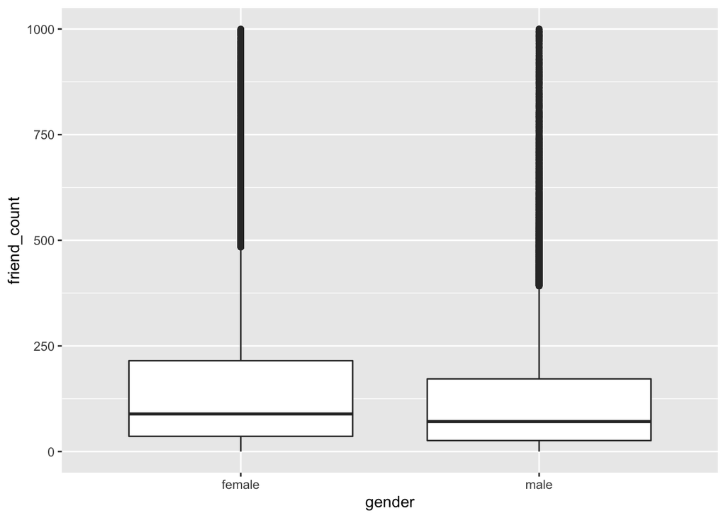

```r
qplot(x = gender, y = friend_count,
      data = subset(pf, !is.na(gender)),
      geom = "boxplot",
      ylim = c(0, 1000))
```

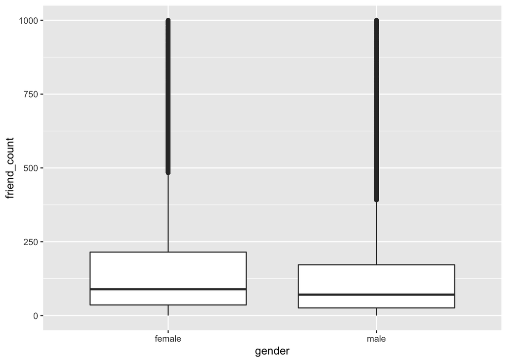

```r
qplot(x = gender, y = friend_count,
      data = subset(pf, !is.na(gender)),
      geom = "boxplot") +
  scale_y_continuous(limits = c(0, 1000))
```

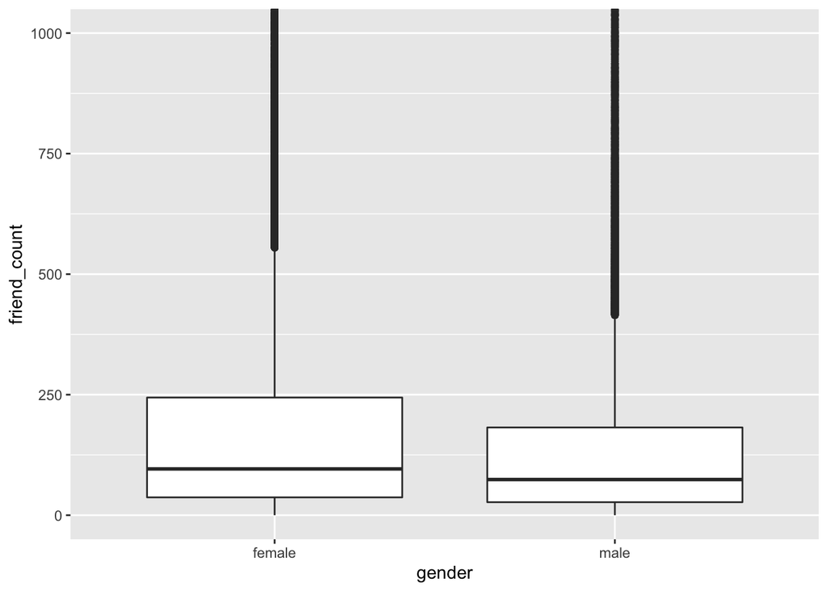

```r
qplot(x = gender, y = friend_count,
      data = subset(pf, !is.na(gender)),
      geom = "boxplot") +
  coord_cartesian(ylim = c(0, 1000))
```

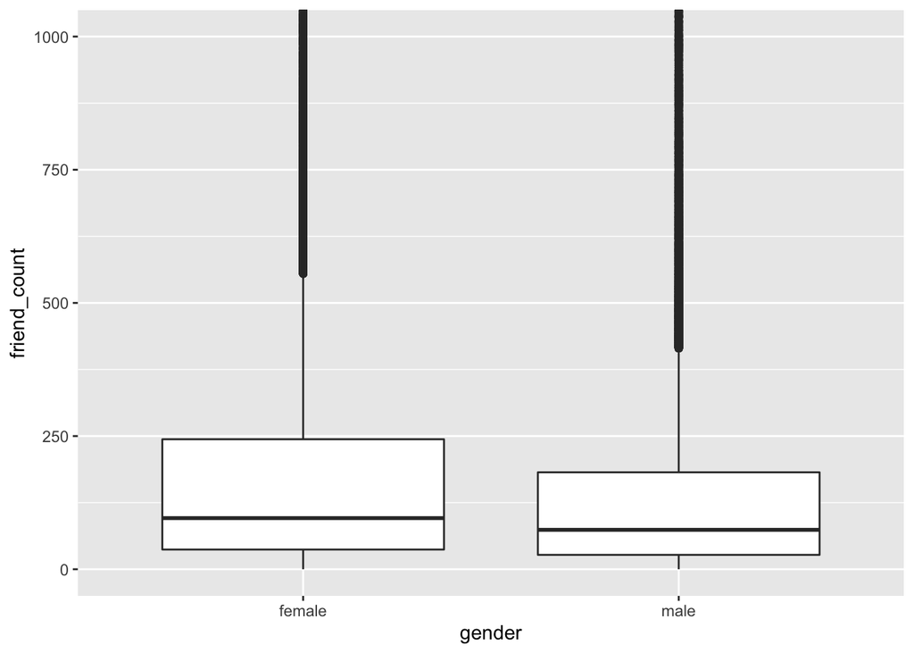

```r
ggplot(data = subset(pf, !is.na(gender)), aes(x = gender, y = friend_count)) +
  geom_boxplot() +
  coord_cartesian(ylim = c(0, 1000))
```